# Math 421 - Midterm

Sophia Drezek

## I. Data Wranggling

1. Download the data file `hdd0318cy.sas7bdat`.
2. Use `read_sas` in library `haven` to read the data.
3. Filter the data to have only patients of the year 2018 (`yod=2018`)
4. Select to work with only following variables:

*Notice*: You may want to save the current data to your computer for easy access later. To save the data file use `write_csv(df, 'midterm.csv')`, for example.

```
## # A tibble: 6 × 49
##     yod payfix pay_ub92   age   sex raceethn provider   moa   yoa   mod admtype
##   <dbl> <lgl>     <dbl> <dbl> <dbl>    <dbl>    <dbl> <dbl> <dbl> <dbl>   <dbl>
## 1    18 NA            9     0     1        1     7214     1    18     1       4
## 2    18 NA            2    76     2        1     7214     1    18     1       3
## 3    18 NA            6    50     2        1     7214    12    17     1       2
## 4    18 NA            4     0     1        7     7214     1    18     1       4
## 5    18 NA           13     0     1        1     7214    12    17     1       4
## 6    18 NA            4     0     2        9     7214    12    17     1       4
## # … with 38 more variables: asource <chr>, preopday <dbl>, los <dbl>,
## #   service <chr>, icu <chr>, ccu <chr>, dispub92 <chr>, payer <chr>,
## #   drg <dbl>, trandb <chr>, randbg <chr>, randbs <chr>, orr <chr>, anes <chr>,
## #   seq <chr>, lab <chr>, dtest <chr>, ther <chr>, blood <chr>, phar <chr>,
## #   other <chr>, patcon <chr>, bwght <lgl>, total <chr>, tot <dbl>,
## #   ecodub92 <chr>, b_wt <chr>, pt_state <chr>, diag_adm <chr>, ancilar <chr>,
## #   campus <dbl>, er_fee <chr>, er_chrg <chr>, er_mode <dbl>, obs_chrg <chr>, …
```

5. What are variables that have missing values?

```
##      yod   payfix pay_ub92      age      sex raceethn provider      moa
##        0   131478        0        0        0     3950        0        0
##      yoa      mod  admtype  asource preopday      los  service      icu
##        0        0        1        6    60486        0        0        0
##      ccu dispub92    payer      drg   trandb   randbg   randbs      orr
##        0        0        0        0        0        0        0        0
##     anes      seq      lab    dtest     ther    blood     phar    other
##        0        0        0        0        0        0        0        0
##   patcon    bwght    total      tot ecodub92     b_wt pt_state diag_adm
##        0   131478        0        0   104339        0        3       50
##  ancilar   campus   er_fee  er_chrg  er_mode obs_chrg obs_hour psycchrg
##        0        0        0        0    12158        0    77343        0
## nicu_day
##   124090
```

6. Remove all variables with missing values.

```
## # A tibble: 6 × 37
##     yod pay_ub92   age   sex provi…¹   moa   yoa   mod   los service icu   ccu
##   <dbl>    <dbl> <dbl> <dbl>   <dbl> <dbl> <dbl> <dbl> <dbl> <chr>   <chr> <chr>
## 1    18        9     0     1    7214     1    18     1     2 00      0000… 0000…
## 2    18        2    76     2    7214     1    18     1     1 00      0000… 0000…
## 3    18        6    50     2    7214    12    17     1     3 00      0000… 0000…
## 4    18        4     0     1    7214     1    18     1     4 00      0000… 0000…
## 5    18       13     0     1    7214    12    17     1    35 00      0000… 0000…
## 6    18        4     0     2    7214    12    17     1    17 00      0000… 0000…
## # … with 25 more variables: dispub92 <chr>, payer <chr>, drg <dbl>,
## #   trandb <chr>, randbg <chr>, randbs <chr>, orr <chr>, anes <chr>, seq <chr>,
## #   lab <chr>, dtest <chr>, ther <chr>, blood <chr>, phar <chr>, other <chr>,
## #   patcon <chr>, total <chr>, tot <dbl>, b_wt <chr>, ancilar <chr>,
## #   campus <dbl>, er_fee <chr>, er_chrg <chr>, obs_chrg <chr>, psycchrg <chr>,
## #   and abbreviated variable name ¹provider
```

7. Refer to the data description in the file `HDD2015-18cy6-20-19.docx`, which variable recording the month of admission?, which variable recording the month of discharge?

Month of admission - moa Month of discharge - mod

8. Which month admitted the most number of patients? Which month admitted the most number of male patients?

```
## # A tibble: 12 × 2
##    moa       n
##    <fct> <int>
##  1 10    11408
##  2 5     11404
##  3 1     11309
##  4 8     11199
##  5 4     11174
##  6 3     11073
##  7 7     10962
##  8 12    10698
##  9 6     10690
## 10 9     10666
## 11 11    10636
## 12 2     10259
```

```
## # A tibble: 12 × 2
## # Groups:   moa [12]
##    moa       n
##    <fct> <int>
##  1 10     5164
##  2 5      5066
##  3 8      5028
##  4 4      4989
##  5 3      4978
##  6 1      4970
##  7 7      4910
##  8 12     4855
##  9 6      4810
## 10 11     4800
## 11 9      4683
## 12 2      4546
```

9. Which month has the most number of teenage female patients?

```
## # A tibble: 12 × 2
##    moa       n
##    <fct> <int>
##  1 3       226
##  2 5       220
##  3 10      212
##  4 12      208
##  5 1       207
##  6 9       196
##  7 4       187
##  8 11      177
##  9 2       172
## 10 8       172
## 11 7       171
## 12 6       169
```

10. Which provider has the most number of female patients in October?

```
## # A tibble: 12 × 2
##    provider     n
##    <fct>    <int>
##  1 7205      1517
##  2 7214      1224
##  3 7204       872
##  4 7210       699
##  5 7209       351
##  6 7206       333
##  7 7213       317
##  8 7201       294
##  9 7216       256
## 10 7202       212
## 11 7211       122
## 12 7215        46
```

11. Are female patients older than male patients, on average?

```
## # A tibble: 3 × 2
##   sex   avg_age
##   <fct>   <dbl>
## 1 1        51.5
## 2 2        50.9
## 3 9        43
```

12. Calculate the average age of patients by months. Which month has the oldest patients on average age?

```
## # A tibble: 12 × 2
##    moa   avg_age
##    <fct>   <dbl>
##  1 1        51.8
##  2 6        51.5
##  3 12       51.5
##  4 4        51.4
##  5 7        51.3
##  6 2        51.2
##  7 3        51.1
##  8 11       51.0
##  9 8        50.9
## 10 10       50.8
## 11 5        50.6
## 12 9        50.6
```

13. What is the name of the provider that has the highest total charge?

```
## # A tibble: 12 × 2
##    provider max_total_charge
##    <fct>               <dbl>
##  1 7214              3402056
##  2 7205              2991708
##  3 7215              2418518
##  4 7216              1532326
##  5 7202              1477944
##  6 7210              1375171
##  7 7204              1040507
##  8 7206               802758
##  9 7213               608086
## 10 7201               365044
## 11 7211               331604
## 12 7209               282223
```

14. What is the name of the provider that has the least total charge for teenage male on average?

```
## # A tibble: 12 × 2
##    provider avg_total_charge
##    <fct>               <dbl>
##  1 7206               10360.
##  2 7201               14434.
##  3 7210               18586.
##  4 7211               19742.
##  5 7213               22618.
##  6 7216               24060.
##  7 7204               24989.
##  8 7209               26573.
##  9 7214               28950
## 10 7202               29389.
## 11 7205               40215.
## 12 7215              100440.
```

15. Create a season (Spring, Summer, Fall, Winter) variable. Calculate the length of stays by season. Which season has the longest length of stays on average?

```
## # A tibble: 4 × 2
##   season avg_LOS
##   <chr>    <dbl>
## 1 Summer    4.96
## 2 Fall      4.96
## 3 Winter    4.93
## 4 Spring    4.84
```

16. On average, how much a 20 year-old male get charged for staying 1 day in the Fall season?

```
## # A tibble: 1 × 1
##   avg_charge
##        <dbl>
## 1      16511
```

17. Write a paragraph to summarize the section and give your comments on the results. You could do some other calculations to support your points.

There were a lot of interesting findings in this data. When looking at the monthly breakdown, the most patients were admitted in the month of October and the average age of both males and females admitted were around 50 years old with males being slightly higher at 51.49 years old and females being 50.86 years old. The average length of stay per season was just under 5 days. I then looked at the breakdown of total charges. Provider 7214 has the highest total charge, which is 3,402,056 dollars and the next highest charge is just under 3 million dollars. The least total charge for a teen male was approximately 10,000 dollars, which is very high for the lowest charge. Another shocking finding was that the average cost of a one day stay for a 20 year old male is 16,511 dollars. Just for one day! These were the most significant findings.

## II. Data Visualization

```
## # A tibble: 6 × 38
##     yod pay_ub92   age sex   provi…¹ moa     yoa mod     los service icu   ccu
##   <dbl>    <dbl> <dbl> <fct> <fct>   <fct> <dbl> <fct> <dbl> <chr>   <chr> <chr>
## 1    18        9     0 1     7214    1        18 1         2 00      0000… 0000…
## 2    18        2    76 2     7214    1        18 1         1 00      0000… 0000…
## 3    18        6    50 2     7214    12       17 1         3 00      0000… 0000…
## 4    18        4     0 1     7214    1        18 1         4 00      0000… 0000…
## 5    18       13     0 1     7214    12       17 1        35 00      0000… 0000…
## 6    18        4     0 2     7214    12       17 1        17 00      0000… 0000…
## # … with 26 more variables: dispub92 <chr>, payer <chr>, drg <dbl>,
## #   trandb <chr>, randbg <chr>, randbs <chr>, orr <chr>, anes <chr>, seq <chr>,
## #   lab <chr>, dtest <chr>, ther <chr>, blood <chr>, phar <chr>, other <chr>,
## #   patcon <chr>, total <chr>, tot <dbl>, b_wt <chr>, ancilar <chr>,
## #   campus <fct>, er_fee <chr>, er_chrg <chr>, obs_chrg <chr>, psycchrg <chr>,
## #   season <chr>, and abbreviated variable name ¹provider
```

Continue with the data from part I.

1. Provides at least 10 meaningful plots. Comments on the plots. All plots should have title, caption, appropriate labels on x and y-axis

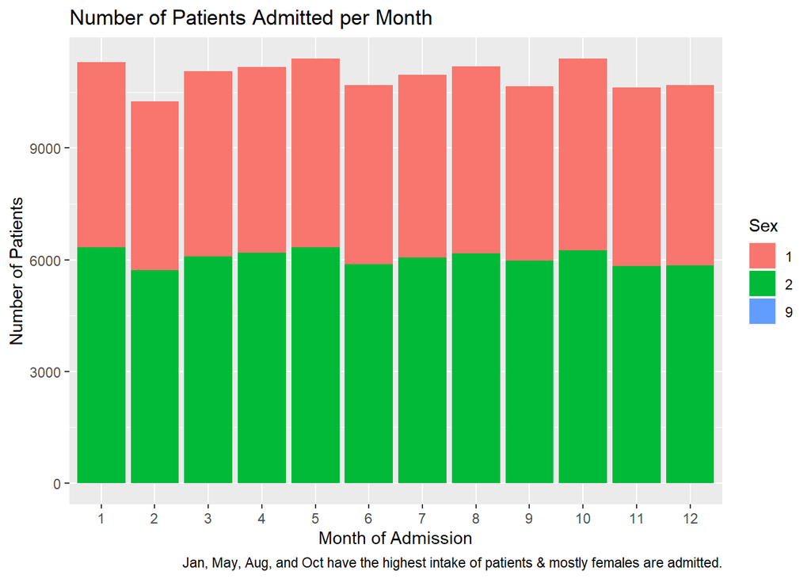

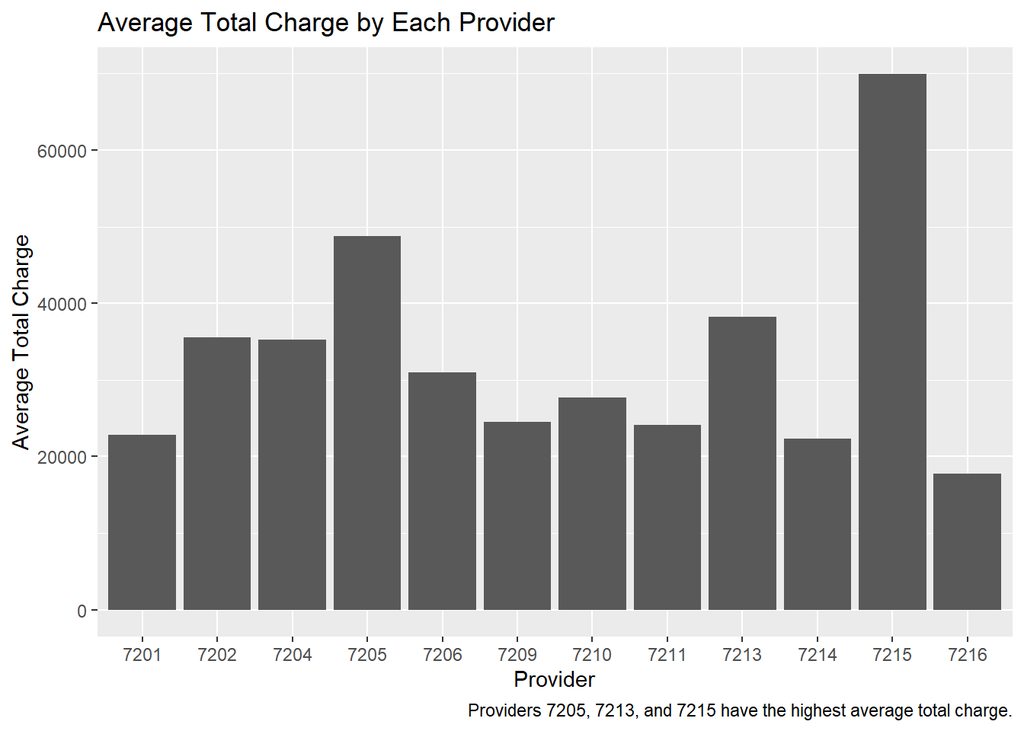

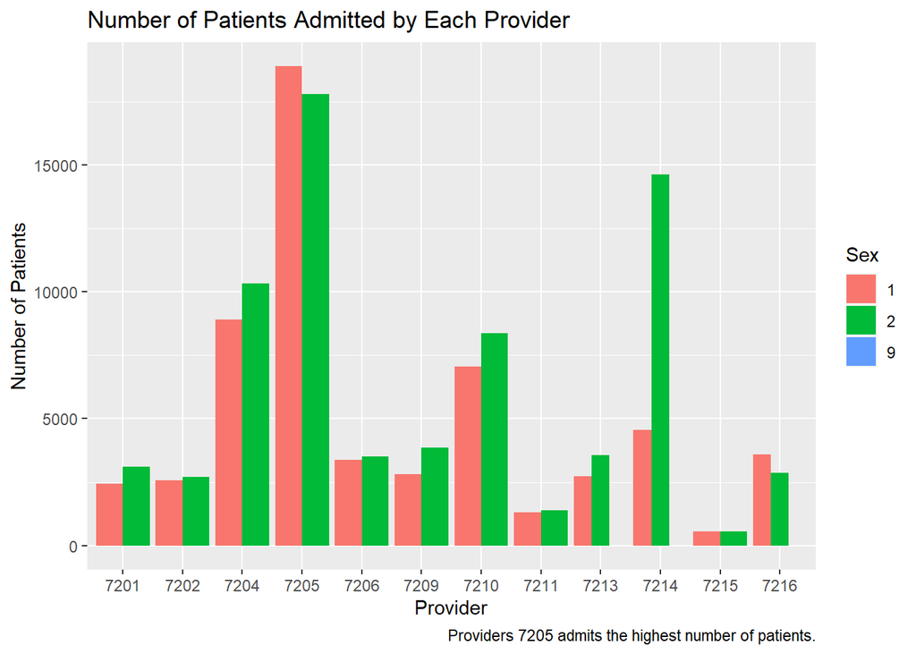

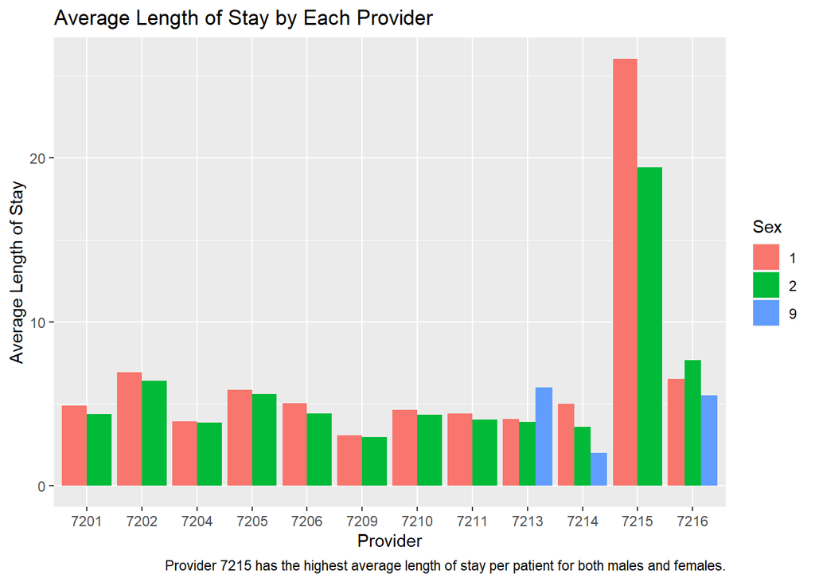

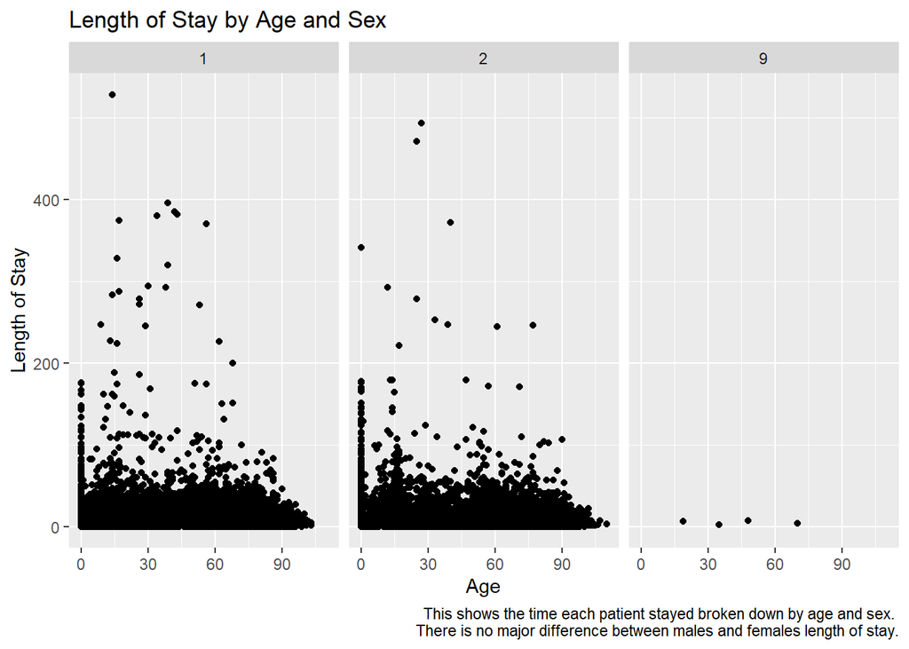

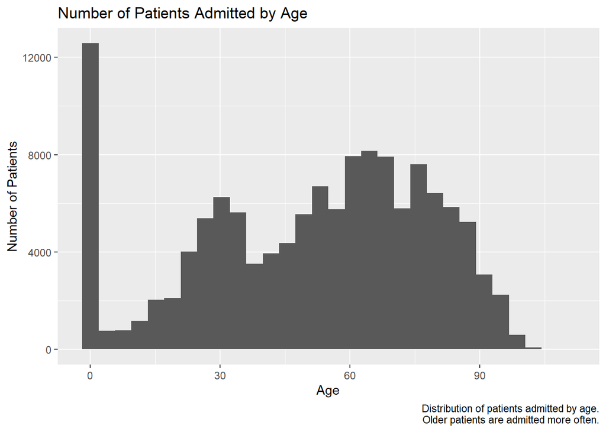

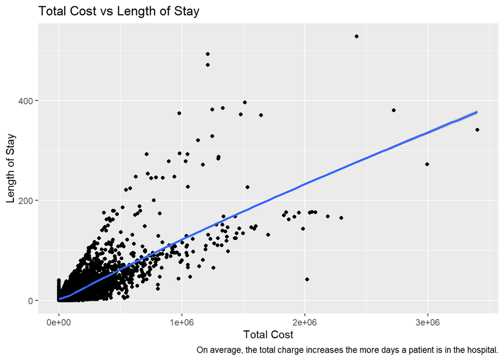

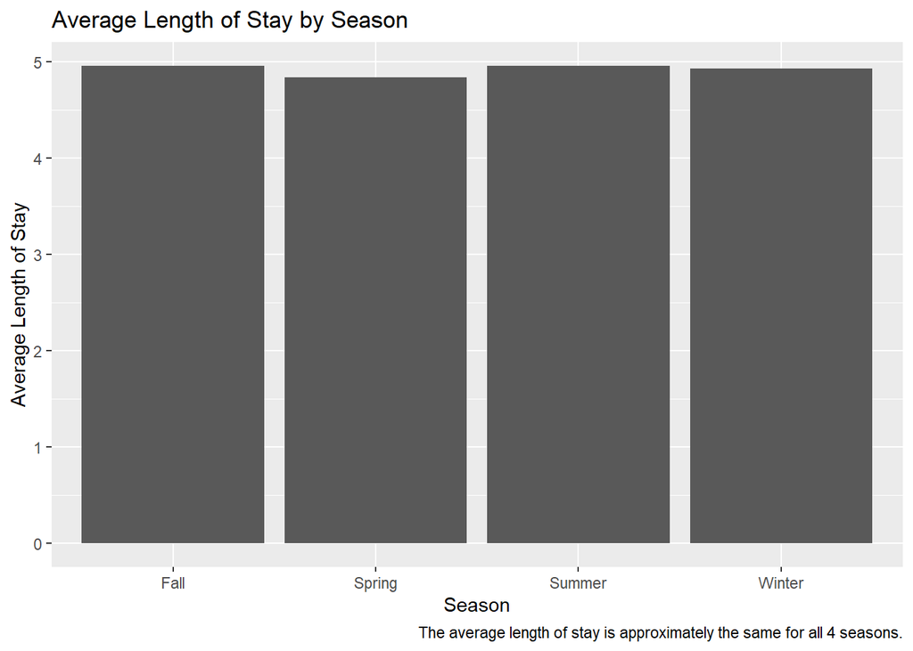

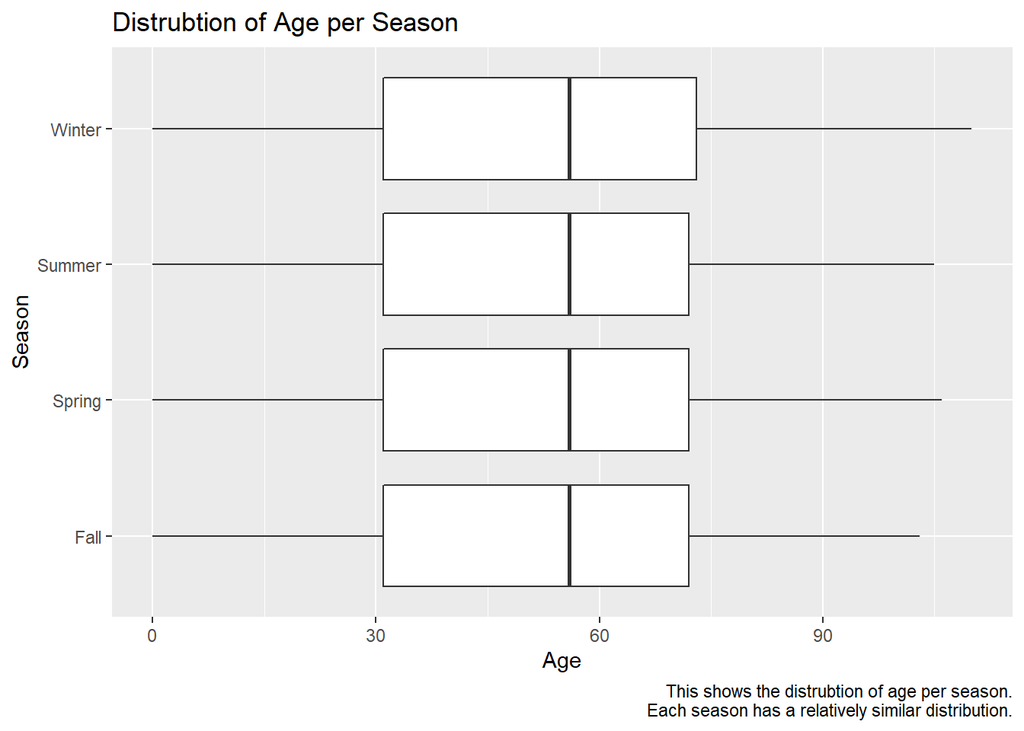

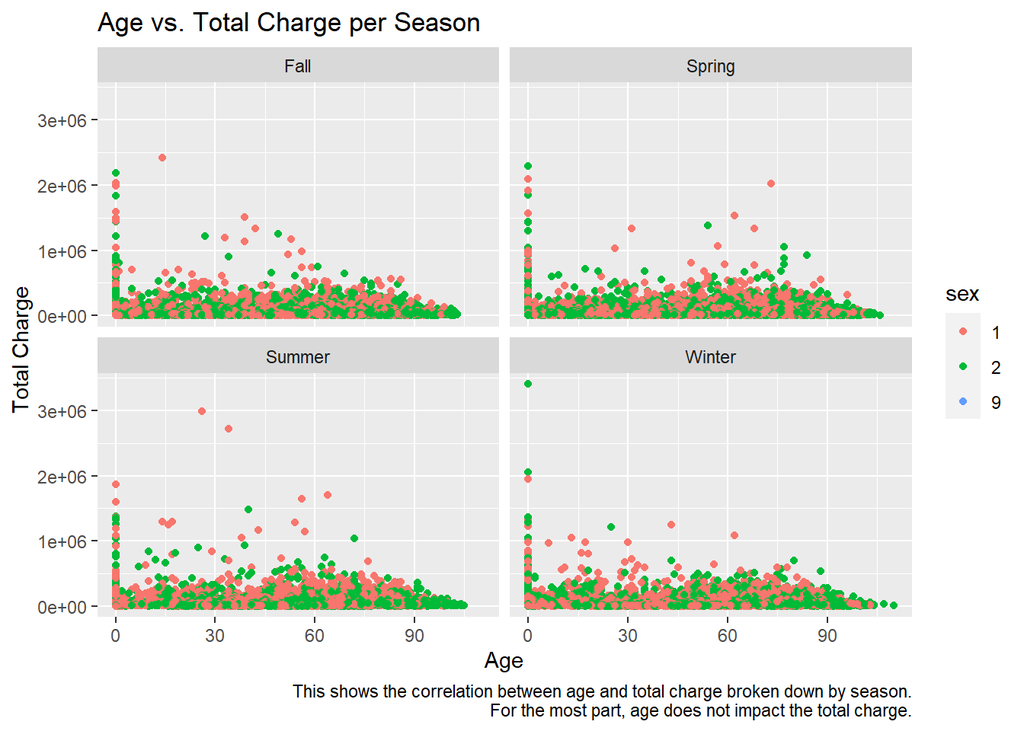

2. Make an animation plot.

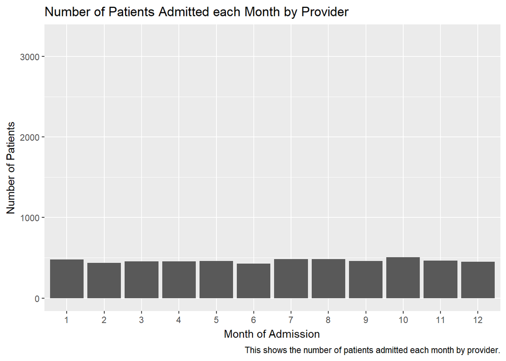

3. Write a paragraph to summarize the section and give your comments on the results.

I first looked at the number of patients admitted per month. January, May, August, and October have the highest intake of patients, although all months are similar. In all months, there were more females admitted than males. I then looked at the data breakdown by provider, starting with the average total charge by each provider. Providers 7215, 7205, and 7213 have the highest average total charge, but provider 7215 is much higher than the rest. In regard to the number of patients admitted by each provider, provider 7205 admits the highest number of patients for both males and females. Provider 7215 has the highest average length of stay per patient for both males and females, which is probably why their average total cost is higher than the other providers. There was no major difference between males and females’ length of stay. When looking at the distribution of patients admitted by age, I found that older patients are admitted more often. On average, the total charge increases the more days a patient is in the hospital, which makes a lot of sense. Other findings include that the average length of stay is approximately the same for all 4 seasons and each season has a relatively similar distribution. For the most part, age does not impact the total charge.

## III. Predictive Models

Continue with the data from part I. Make sure you do not have any missing values in the data. Use the follows as the target and input variables:

```
##      yod pay_ub92      age      sex provider      moa      yoa      mod
##        0        0        0        0        0        0        0        0
##      los  service      icu      ccu dispub92    payer      drg   trandb
##        0        0        0        0        0        0        0        0
##   randbg   randbs      orr     anes      seq      lab    dtest     ther
##        0        0        0        0        0        0        0        0
##    blood     phar    other   patcon    total      tot     b_wt  ancilar
##        0        0        0        0        0        0        0        0
##   campus   er_fee  er_chrg obs_chrg psycchrg   season
##        0        0        0        0        0        0
```

```
## # A tibble: 6 × 38
##     yod pay_ub92   age sex   provi…¹ moa     yoa mod     los service icu   ccu
##   <dbl>    <dbl> <dbl> <fct> <fct>   <fct> <dbl> <fct> <dbl> <chr>   <chr> <chr>
## 1    18        9     0 1     7214    1        18 1         2 00      0000… 0000…
## 2    18        2    76 2     7214    1        18 1         1 00      0000… 0000…
## 3    18        6    50 2     7214    12       17 1         3 00      0000… 0000…
## 4    18        4     0 1     7214    1        18 1         4 00      0000… 0000…
## 5    18       13     0 1     7214    12       17 1        35 00      0000… 0000…
## 6    18        4     0 2     7214    12       17 1        17 00      0000… 0000…
## # … with 26 more variables: dispub92 <chr>, payer <chr>, drg <dbl>,
## #   trandb <chr>, randbg <chr>, randbs <chr>, orr <chr>, anes <chr>, seq <chr>,
## #   lab <chr>, dtest <chr>, ther <chr>, blood <chr>, phar <chr>, other <chr>,
## #   patcon <chr>, total <chr>, tot <dbl>, b_wt <chr>, ancilar <chr>,
## #   campus <fct>, er_fee <chr>, er_chrg <chr>, obs_chrg <chr>, psycchrg <chr>,
## #   season <chr>, and abbreviated variable name ¹provider
```

*Target Variable*: Create the target variable taking value of

- `low` if the total charge of a patient (`tot`) is smaller than the median of the total charge, and
- `high` otherwise.

*Input Variables*:

- “age”,“sex”,“provider”,“moa”,“mod”,“campus”, ‘los’

```
## # A tibble: 6 × 8
##     age sex   provider moa   mod   campus   los target
##   <dbl> <fct> <fct>    <fct> <fct> <fct>  <dbl> <chr>
## 1     0 1     7214     1     1     0          2 low
## 2    76 2     7214     1     1     0          1 high
## 3    50 2     7214     12    1     0          3 high
## 4     0 1     7214     1     1     0          4 low
## 5     0 1     7214     12    1     0         35 high
## 6     0 2     7214     12    1     0         17 high
```

1. Use `filter` function to filter out rows where `raceethn==''` or `admtype==''`. Make sure all the categorical variables are factor, numeric variables are numeric. Set Training : Testing Split = 10 : 90
2. Train a decision tree using `rpart`. Plot the decision tree. Plot the variable importance ranked by the tree.

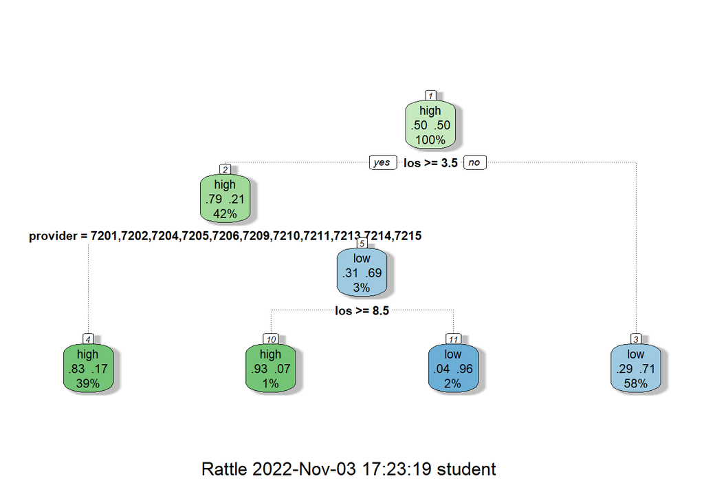

```
##          los     provider       campus          age          sex
## 15951.021186  3110.522900   718.288657   196.051878     1.070557
```

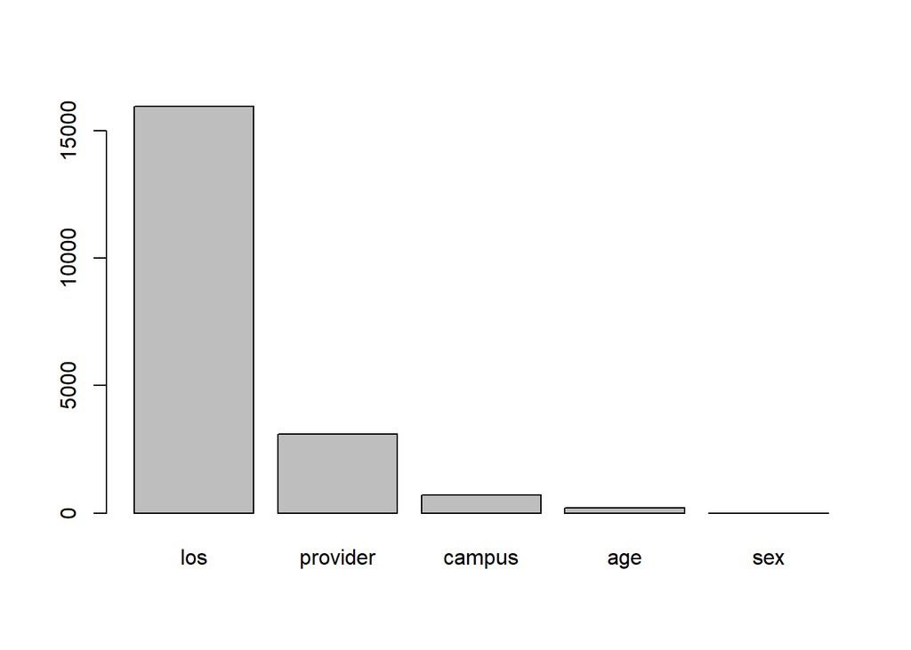

3. Using caret for this question. Set `Training Control` to be: Use Cross-Validation of 5 folds across all models. Train & tune at least 2 different models (i.e. two different values for `method=` in the train function of caret). Plot the hyper-parameter tuning plots for each model.

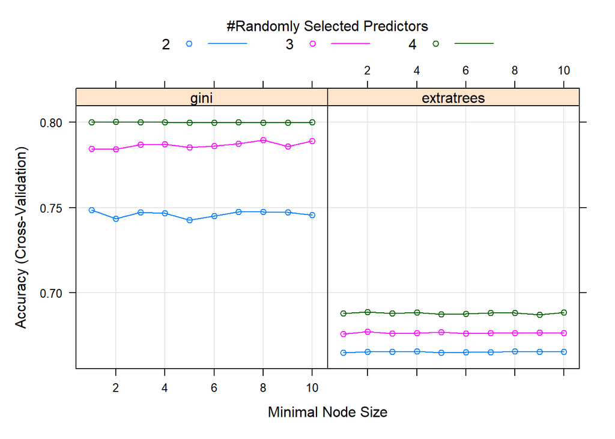

```
##  Accuracy
## 0.8007911
```

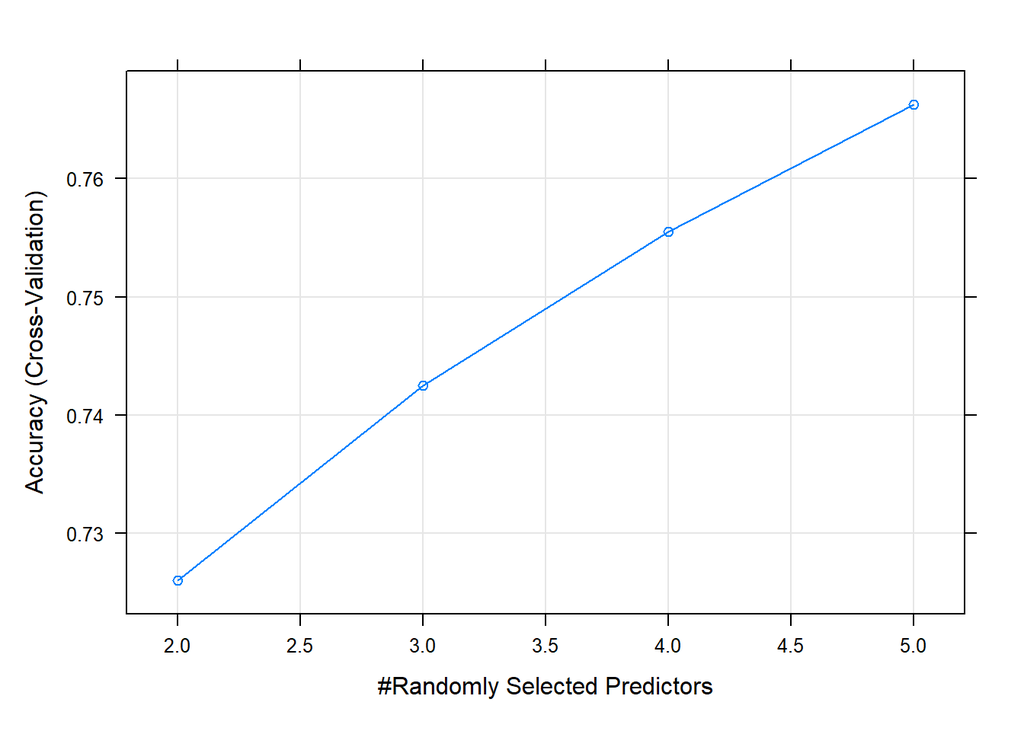

```
##  Accuracy
## 0.7626074
```

4. Plot the comparison of the models in 3.

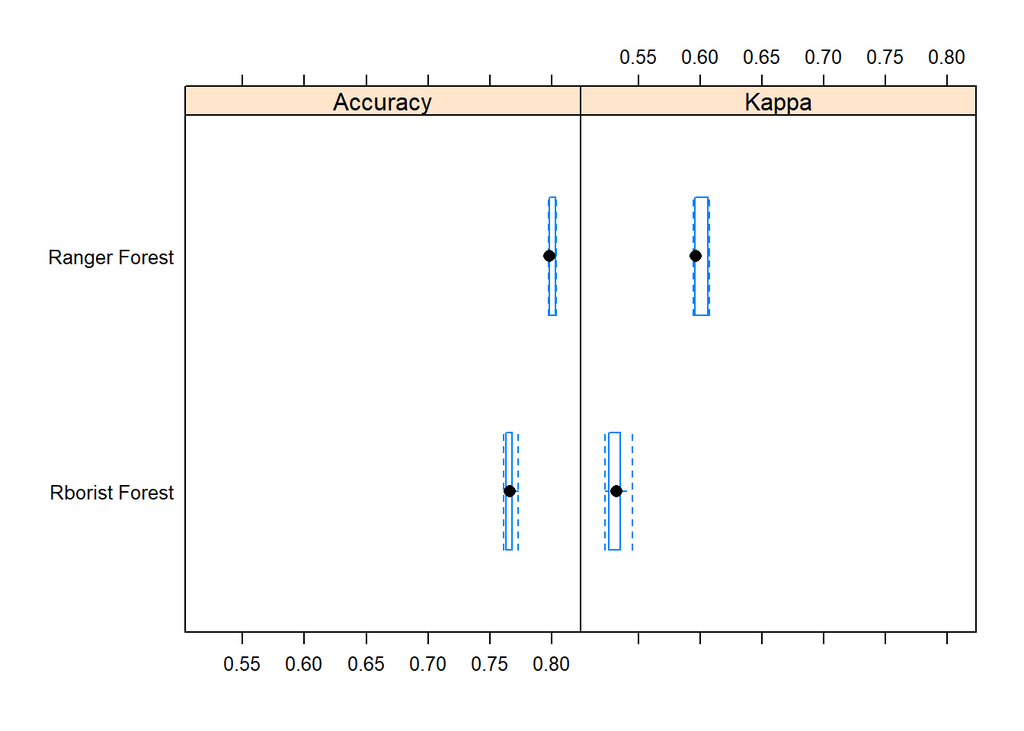

5. What is your final selection for the model? Test the accuracy of your final model on the test data.

```
##  Accuracy
## 0.8007911
```

6. Create another `target` variable (binary), decide the input variables and redo 1 to 5.

[figure not shown]

```
##          los     provider       campus          age          sex
## 16009.823336  3140.817531   731.330992   195.712319     1.072832
```

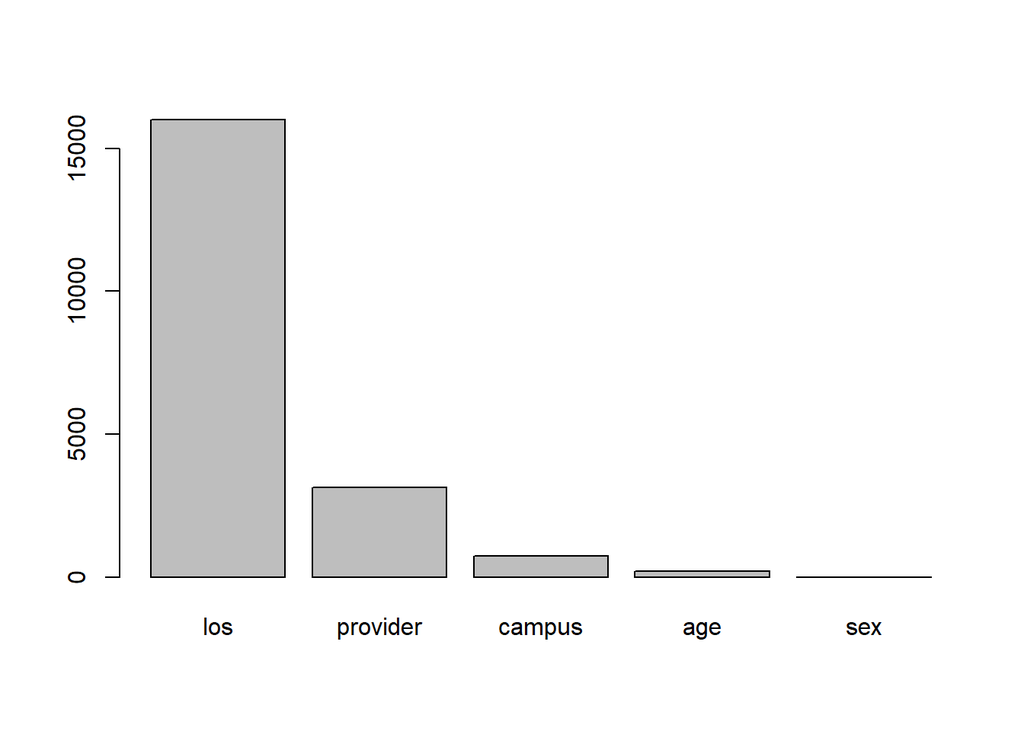

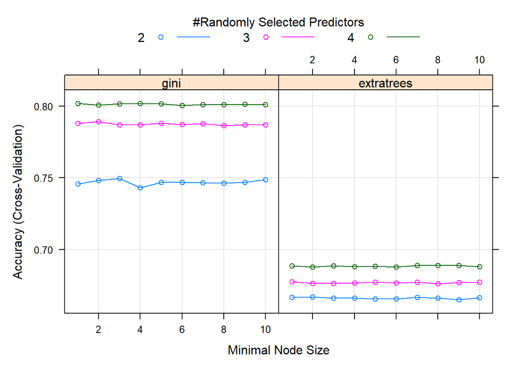

```
##  Accuracy
## 0.7928805
```

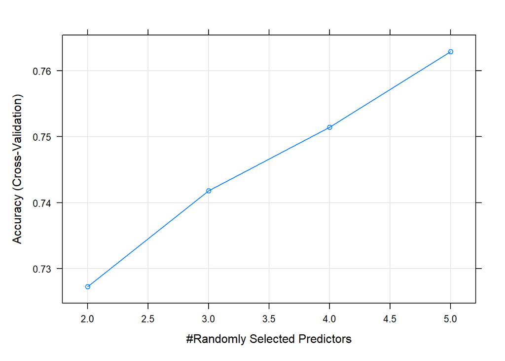

```
##  Accuracy
## 0.7648893
```

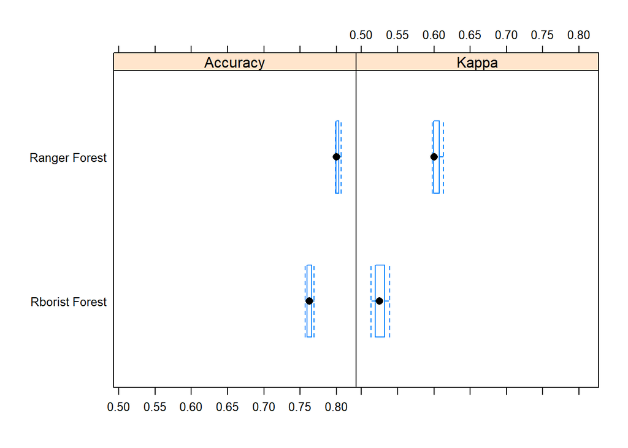

```
##  Accuracy
## 0.7927284
```